title: “Example5” output: html_document: keep_md: true —

# Fitting a Matérn covariance to a (possibly incomplete) lattice observation

The `CGEMEV` R package (dependent on the fields, spam, SpatialVx and RCPP packages) provides

- a simple function for simulating realizations of a stationary isotropic Gaussian process when the correlation belongs to the common Matérn family with smoothness index *nu > 0*
- tools for estimating, when *nu* is known and the level *sigma<sub>NOISE</sub>* of the possible ``measurement errors’’ is either known or unknown, the correlation range, also called ‘’decorrelation length’’ (or its inverse that will be denoted *theta*) from one realization on a (possibly incomplete) lattice. The variance of the field is simply estimated by the empirical variance that will be denoted *b<sub>EV</sub>*.

These tools implement the estimation method proposed in Girard, D.A., 2016, Asymptotic near-efficiency of the Gibbs-energy and empirical-variance estimating functions for fitting Matérn models I: Densely sampled processes. Statistics and Probability Letters 110, 191-197, and in the preprint https://hal.archives-ouvertes.fr/hal-00515832 .

In this first version of `CGEMEV`, the region of missing observations is defined as a union of disks.

These R-fonctions can be applied to a quite large grid even on a laptop (for example 512x512, provided the ‘’extension factor’’ required for simulation, see below, is not too big). Indeed quite fast computation of the quadratic form which occurs in the estimating equation is possible by using a conjugate-gradient (CG) solver preconditioned by a classical factored sparse approximate inverse (FSAI) preconditioning, since the matrix-vector product, required in each CG iteration, can be obtained via FFT from the standard embedding of the correlation matrix in a circulant matrix.

## Contents

- Setting the probabilistic model
- Simulating one realization
- Plotting (and saving) several realizations
- Setting the uncomplete lattice
- Plotting data
- Computing (and plotting) the estimating function at log-equispaced ranges
- Estimating theta and the micro-ergodic parameter

## Setting the probabilistic model

```r
library(CGEMEV)
library(pdist)
n1grid <- 108
# gaussian matern creation
nu <-0.5
effectiveRange <- 0.0833333
gm <- gaussian.matern(grid.size=n1grid,smoothness=nu,
                      range=effectiveRange/sqrt(2*nu),factor=2)
```

NB: in the previous setting, `factor=2` specifies the required extension factor (assumed, for simplicity, to be an integer) of the observation domain. Indeed for this example the choice `factor=1` would entail (when calling `simulate(gm)`) the message “FFT of covariance has negative values” which means that generating a realization via the classical embedding method (which doubles each length of the considered rectangular domain) would not work.

## Simulating one realization

This is simply:

```r
set.seed(321)  # so that it is reproducible #
simulate(gm)
```

## Plotting (and saving) several realizations

We can plot (and save), the previous realization and, for example, 5 further realizations:

```r
fullLattice.sixZs<- array(NA,c(n1grid*n1grid,6))
set.panel(2,3)
```

```
## plot window will lay out plots in a 2 by 3 matrix
```

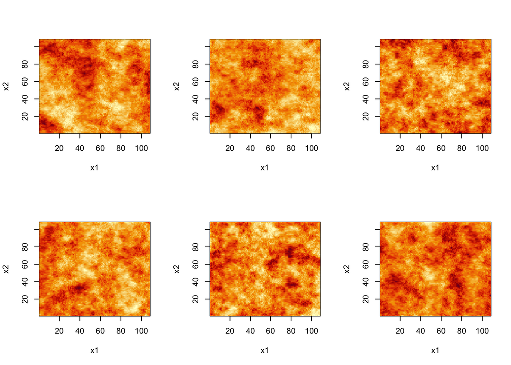

```r
plot(gm)
fullLattice.sixZs[,1]<-gm$look[1:gm$n1,1:gm$n1]
ut <- system.time(
for (indexReplcitate in 2:6){
  set.seed(320+indexReplcitate)
  simulate(gm)
  plot(gm)
  fullLattice.sixZs[,indexReplcitate]<-gm$look[1:gm$n1,1:gm$n1]
})
```

The following timing (in seconds) is for a MacBookPro 13inch 2018 - Intel I5 2.3GHz - ram8GB :

```r
ut   # for the simulation of 5 realizations :
```

```
##    user  system elapsed
##   1.156   0.038   1.209
```

## Setting the uncomplete lattice

Let us now define the regions (actually 5 disks) where the observations will be missing, and precompute the preconditioning matrix:

```r
# md=missing.domains
listOfHalfDiameters <- c(1,0.4,0.2,0.1,0.05)*sqrt(.1/ pi)

listOfCenters <- t(matrix(c(c(0.5+sqrt(.1/ pi),0.5+sqrt(.1/ pi)),c(0.1+sqrt(.1/ pi),
0.05+sqrt(.1/ pi)),c(0.8,0.25),c(0.2,0.8),c(0.3,0.7)),2,length(listOfHalfDiameters)))


ex1.md <- list(
  list(center=listOfCenters[1,],radius= listOfHalfDiameters[1]),
list(center=listOfCenters[2,],radius= listOfHalfDiameters[2]),
list(center=listOfCenters[3,],radius= listOfHalfDiameters[3]),
list(center=listOfCenters[4,],radius= listOfHalfDiameters[4]),
list(center=listOfCenters[5,],radius= listOfHalfDiameters[5])
)
# gd=grid.domain
print(system.time(ex1WithN1eq108And5missindDisks.gd <- grid.domain(missing.domains=ex1.md,grid.size=n1grid,
            smoothness=nu)))
```

```
##    user  system elapsed
##   5.119   0.030   5.172
```

Size of the data set:

```r
(nObs <- dim(ex1WithN1eq108And5missindDisks.gd$sparseG)[1])
```

```
## [1] 10274
```

Average width of the sparse preconditioner:

```r
length(ex1WithN1eq108And5missindDisks.gd$sparseG) / dim(ex1WithN1eq108And5missindDisks.gd$sparseG)[1]
```

```
## [1] 64.51041
```

## Plotting observation sites

Each dataset is made up of the observations of one realization of the previous type at the following points:

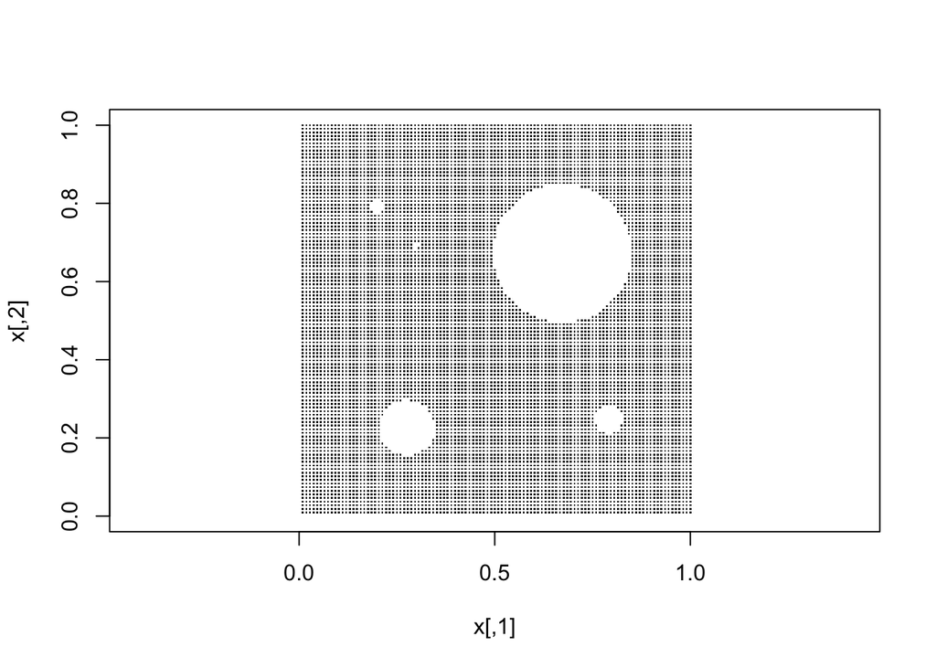

```r
xFull<- (1./n1grid)*matrix( c(rep(1: n1grid, n1grid),rep(1: n1grid,each= n1grid)), ncol=2)
x <- xFull[!ex1WithN1eq108And5missindDisks.gd$missing.sites,]
plot(x,asp=1, xlim=c(0,1), ylim=c(0,1), pch=".")
```

## No-noise case : Computing (and plotting) the estimating function at log-equispaced ranges

Choose a grid of candidates for the range parameter (more precisely, for the inverse-range parameter denoted `theta`) at which the estimating function is computed:

```r
(thetaTrue  <- 1/gm$range)
```

```
## [1] 12
```

```r
candidateThetas1DGrid <- thetaTrue * 10**seq(-0.8,0.8,,15)
```

Consider the first one of the above realizations, and the naive variance estimator *b<sub>EV</sub>*:

```r
# only observed outside the disks:
#z <- gm$look[1:gm$n1,1:gm$n1][!ex1WithN1eq108And5missindDisks.gd$missing.sites]
indexReplcitate <- 1
z <- fullLattice.sixZs[,indexReplcitate][!ex1WithN1eq108And5missindDisks.gd$missing.sites]
#
(bEV  <- mean(z**2))
```

```
## [1] 1.300885
```

For this dataset `z`, let us give the whole output of the function `fsai11Precond.GEevalOnThetaGrid()` :

```r
(out <- fsai11Precond.GEevalOnThetaGridNEW(z,candidateThetas1DGrid,nu=gm$smoothness,
grid.domain=ex1WithN1eq108And5missindDisks.gd,tolPGC=1e-04)
)
```

```
## $values
##            [,1]
##  [1,] 6.0990232
##  [2,] 4.6887839
##  [3,] 3.6051107
##  [4,] 2.7725302
##  [5,] 2.1330625
##  [6,] 1.6421924
##  [7,] 1.2657789
##  [8,] 0.9776935
##  [9,] 0.7580262
## [10,] 0.5917741
## [11,] 0.4678584
## [12,] 0.3785238
## [13,] 0.3190425
## [14,] 0.2877870
## [15,] 0.2866724
##
## $niterForY
##  [1] 15  9 13 10  9  7  6  6  7 10 14 23 14  9  6
```

Let us repeat this computation for the five next data sets obtained from the above realizations, and plot the results:

```r
set.panel(2,3)
```

```
## plot window will lay out plots in a 2 by 3 matrix
```

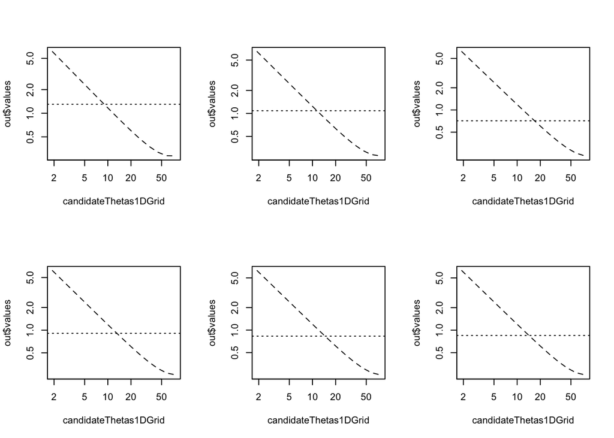

```r
{plot(candidateThetas1DGrid, out$values,  type="l",
                 col=1,lty= "dashed",log="xy")
    abline(h= bEV, lty= "dotted" )
}
ut <- system.time(
for (indexReplcitate in 2:6){
  z <- fullLattice.sixZs[,indexReplcitate][!ex1WithN1eq108And5missindDisks.gd$missing.sites]
  bEV  <- mean(z**2)
  out <-     fsai11Precond.GEevalOnThetaGridNEW(z, candidateThetas1DGrid,
          gm$smoothness, ex1WithN1eq108And5missindDisks.gd ,tolPGC=1e-04)
#
  plot(candidateThetas1DGrid, out$values, type="l",
                 col=1, lty= "dashed",log="xy")
    abline(h= bEV, lty= "dotted")
})
```

Timing for a MacBookPro 13inch 2018 - Intel I5 2.3GHz - ram8GB

```r
ut   # for computing the estimating equation for 5 realizations :
```

```
##    user  system elapsed
##  11.099   0.869  12.007
```

## Estimating theta and the micro-ergodic parameter from noisy observations with (unknown) SNR $= 33^2$, known *sigma<sub>NOISE</sub>*

```r
sigma2Process<- 33^2
sigma2Noise <- 1.
bTrue <- sigma2Process/sigma2Noise

nbReplicates <- 100
bHatEV<-matrix(NA,nbReplicates)
cHatCGEMEV<-matrix(NA, nbReplicates)
thetaHatCGEMEV<-matrix(NA, nbReplicates)
nCGiterationsMaxForY<-matrix(NA, nbReplicates)
#
ut <- system.time(
for (indexReplcitate in 1: nbReplicates){
  set.seed(720+indexReplcitate)
  simulate(gm)
  z <- gm$look[1:gm$n1,1:gm$n1][!ex1WithN1eq108And5missindDisks.gd$missing.sites]
  y <-  sqrt(bTrue)* z +  c(rnorm(nObs))
#
  bEV  <- ( mean(y**2)-sigma2Noise ) / sigma2Noise
  if (bEV <0) {
            break}
  w <-  c(rnorm(nObs))
  out <-     fsaiThreePrecond.fastRandzedCGEMEVbisectionLogScaleSearch(
          sigma2Noise,y,
          w,
          gm$smoothness, ex1WithN1eq108And5missindDisks.gd ,tolPGC=1e-04,
        0.2,50, tolBis=1e-05)

#
  thetaHatCGEMEV[indexReplcitate]<- (out$root)
  cHatCGEMEV[indexReplcitate]<-
                            bEV*(out$root)**(2*gm$smoothness)
  nCGiterationsMaxForY[indexReplcitate]<-
                 max(out$niterCGiterationsHistory)
})
```

```r
ut
```

```
##    user  system elapsed
## 341.275  27.206 369.049
```

Summary of the results:

```r
print(c("log10 of true range =",log(sqrt(2*nu)*gm$range,10)))
```

```
## [1] "log10 of true range =" "-1.07918141976545"
```

```r
summary(log(sqrt(2*nu)/thetaHatCGEMEV,10))
```

```
##        V1
##  Min.   :-1.1923
##  1st Qu.:-1.1315
##  Median :-1.0770
##  Mean   :-1.0741
##  3rd Qu.:-1.0381
##  Max.   :-0.9069
```

```r
cTrue <-  bTrue*(1/gm$range)**(2*gm$smoothness)
summary(cHatCGEMEV/cTrue)
```

```
##        V1
##  Min.   :0.9655
##  1st Qu.:0.9906
##  Median :1.0009
##  Mean   :1.0015
##  3rd Qu.:1.0117
##  Max.   :1.0479
```

```r
sd(cHatCGEMEV/cTrue)
```

```
## [1] 0.01445345
```

This sd can be compared to the CR lower bound for the case known theta and no-noise

```r
sqrt(2/length(z))
```

```
## [1] 0.01395228
```

Let us plot an estimate of the density of the CGEMEV estimates of the effective range, and of the density of the relative errors in the CGEMEV estimates of the microergodic-parameter cTrue:

```r
set.panel(2,2)
```

```
## plot window will lay out plots in a 2 by 2 matrix
```

[output not shown]

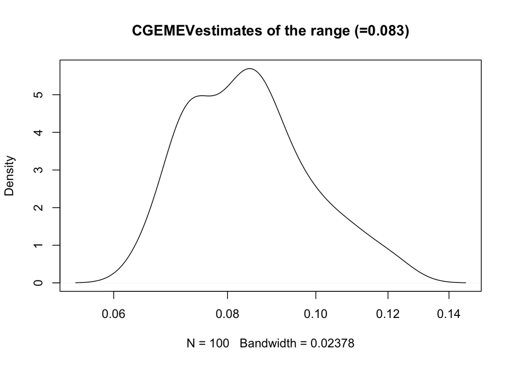

```r
den <- density(log(sqrt(2*nu)/thetaHatCGEMEV,10))
den$x <- 10**(den$x)
plot(den, log="x",main="")
title("CGEMEVestimates of the range (=0.083)")
```

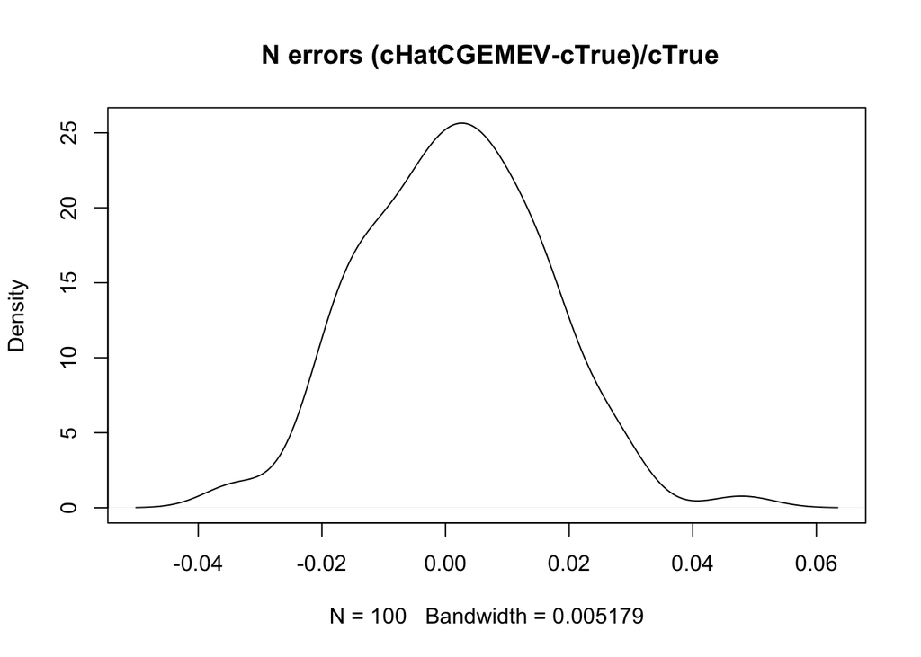

```r
plot(density((cHatCGEMEV-cTrue)/cTrue),main="")
title(" N errors (cHatCGEMEV-cTrue)/cTrue")
```

## Estimating theta and the micro-ergodic parameter from noisy observations with (unknown) SNR $= 33^2$, unknown *sigma<sub>NOISE</sub>*: CGEM-EV-VEZ method

In a first stage, the variance of the noise (or nugget-effect), whose true value $=1$, is estimated by extrapolating at zero the classical semi-variogram (using maximum lag set to 3). THe second stage is a simple “plugin” of this variance in CGEM-EV in place of the true variance :

```r
#################################################################
## definition of sig2noiseByVariogExtrapolAtZeroNew #############
#################################################################
library(SpatialVx)
#help(structurogram.matrix)
sig2noiseByVariogExtrapolAtZeroNew <- function(y,n1grid,n2grid,
maxLag=5)
{#  missingPositions have zero value
    tmp <- array(y,c(n1grid,n2grid))
  #
    outWithMissing<-structurogram.matrix(tmp,zero.out=TRUE,R=maxLag)
    variog<-outWithMissing$vgram
    lag<-outWithMissing$d
    lag2<-lag^2
    quadratic.model <-lm(variog ~ lag + lag2)
    #
    sig2noiseVEZ <-quadratic.model$coefficients[1]
#
sig2noiseVEZ
}
## end of sig2noiseByVariogExtrapolAtZero ################
##########################################################
```

```r
failureOfVEZ<-matrix(FALSE,nbReplicates)
```

```r
sigma2Process<- 33^2
sigma2Noise <- 1.
bTrue <- sigma2Process/sigma2Noise

nbReplicates <-100
bHatEVsigma2NoiseVEZ<-matrix(NA,nbReplicates)
cHatCGEMEVsigma2NoiseVEZ<-matrix(NA, nbReplicates)
thetaHatCGEMEVsigma2NoiseVEZ<-matrix(NA, nbReplicates)
nCGiterationsMaxForYsigma2NoiseVEZ<-matrix(NA, nbReplicates)
sigma2NoiseVEZ<-matrix(NA, nbReplicates)

#
maxLag <-3
ut <- system.time(
for (indexReplcitate in 1: nbReplicates){
  set.seed(720+indexReplcitate)
  simulate(gm)
  z <- gm$look[1:gm$n1,1:gm$n1][!ex1WithN1eq108And5missindDisks.gd$missing.sites]
  y <-  sqrt(bTrue)* z +  c(rnorm(nObs))
# compute bHatEVsigma2NoiseVEZ
  Yrepl<-rep(NA,gm$n1*gm$n1)
      Yrepl[!ex1WithN1eq108And5missindDisks.gd$missing.sites] <- y
      minOfimageMinus1 <- min(Yrepl,na.rm=TRUE)-1
      YreplOffset<-Yrepl-rep(minOfimageMinus1,gm$n1*gm$n1)
      YreplOffsetWithZeroInsteadNA <- YreplOffset
      YreplOffsetWithZeroInsteadNA[is.na(Yrepl)] <-0
      estimation <-
        sig2noiseByVariogExtrapolAtZeroNew(YreplOffsetWithZeroInsteadNA,gm$n1,gm$n1,maxLag=maxLag)
      #
      lowerBound <- 10**(-12)*mean(y**2)
      sigma2NoiseVEZ[indexReplcitate] <- max(c(lowerBound,estimation),na.rm=TRUE)
  if (sigma2NoiseVEZ[indexReplcitate]==lowerBound) failureOfVEZ[indexReplcitate] <- TRUE
    #
  else
  {bEV  <- ( mean(y**2)-sigma2NoiseVEZ[indexReplcitate] )/ sigma2NoiseVEZ[indexReplcitate]
    if (bEV <0) {
            break}
    w <-  c(rnorm(nObs))
    out <-     fsaiThreePrecond.fastRandzedCGEMEVbisectionLogScaleSearch(
           sigma2NoiseVEZ[indexReplcitate] ,y,
          w,
          gm$smoothness, ex1WithN1eq108And5missindDisks.gd ,tolPGC=1e-04,
        0.2,50, tolBis=1e-05)
   #
   #
   thetaHatCGEMEVsigma2NoiseVEZ[indexReplcitate] <- (out$root)
   cHatCGEMEVsigma2NoiseVEZ[indexReplcitate]<-
        ( mean(y**2)-sigma2NoiseVEZ[indexReplcitate] ) * (out$root)**(2*gm$smoothness)
   #
   nCGiterationsMaxForYsigma2NoiseVEZ[indexReplcitate]<-
                 max(out$niterCGiterationsHistory)
  }
})
```

Number of non-failure of VEZ

```r
(numberOfNonFailureOfVEZ <- sum(failureOfVEZ==FALSE))
```

```
## [1] 77
```

Timing for these replicates (including the extrapolations of each empirical varogriam), using a MacBookPro 13inch 2018 - Intel I5 2.3GHz - ram8GB :

```r
ut
```

```
##    user  system elapsed
## 283.839  24.184 308.481
```

Summary of the results:

```r
print(c("log10 of true range =",log(sqrt(2*nu)*gm$range,10)))
```

```
## [1] "log10 of true range =" "-1.07918141976545"
```

```r
summary(log(sqrt(2*nu)/thetaHatCGEMEVsigma2NoiseVEZ,10))
```

```
##        V1
##  Min.   :-1.3128
##  1st Qu.:-1.1655
##  Median :-1.1280
##  Mean   :-1.1157
##  3rd Qu.:-1.0588
##  Max.   :-0.9079
##  NA's   :23
```

```r
cTrue <-  bTrue*(1/gm$range)**(2*gm$smoothness)
summary(cHatCGEMEVsigma2NoiseVEZ/cTrue)
```

```
##        V1
##  Min.   :0.9702
##  1st Qu.:1.0121
##  Median :1.0360
##  Mean   :1.1021
##  3rd Qu.:1.1390
##  Max.   :1.6372
##  NA's   :23
```

```r
sd(cHatCGEMEVsigma2NoiseVEZ/cTrue,na.rm=TRUE)
```

```
## [1] 0.1440577
```

This sd can be compared to the CR lower bound for the case known theta and no-noise

```r
sqrt(2/length(z))
```

```
## [1] 0.01395228
```

Let us plot an estimate of the density of the CGEM-EV-VEZ estimates of the effective range, and of the density of the relative errors in the CGEM-EV-VEZ estimates of the microergodic-parameter cTrue:

[output not shown]

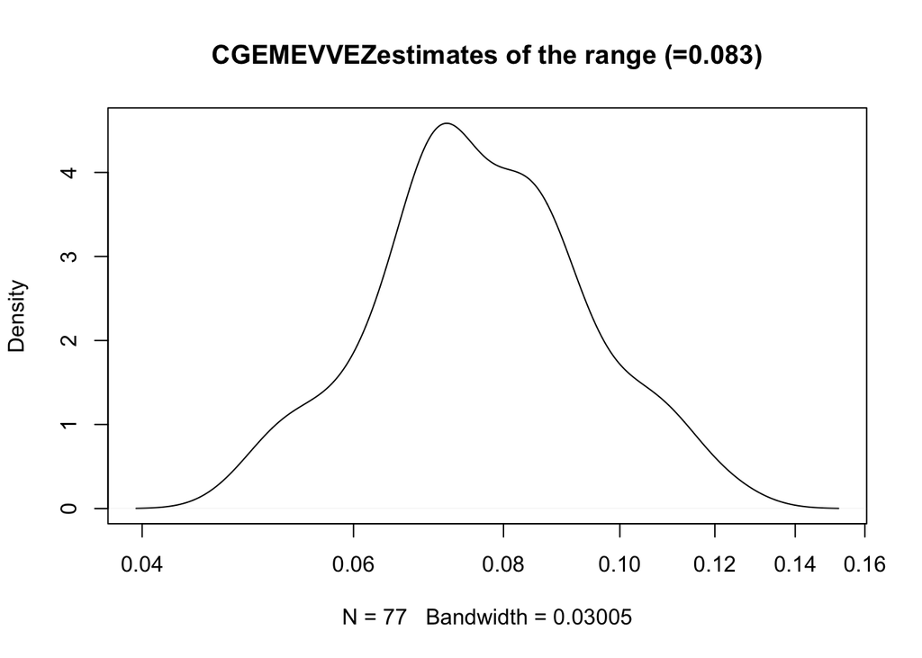

```r
den <- density(log(sqrt(2*nu)/thetaHatCGEMEVsigma2NoiseVEZ,10),na.rm=TRUE)
den$x <- 10**(den$x)
plot(den, log="x",main="")
title("CGEMEVVEZestimates of the range (=0.083)")
```

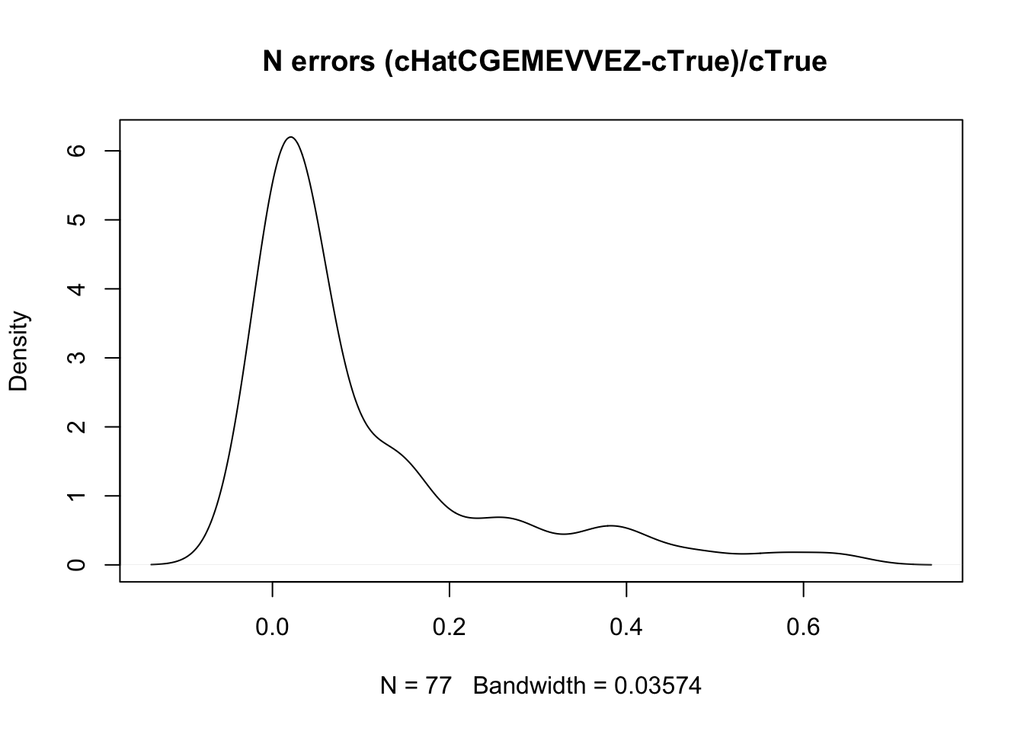

```r
plot(density((cHatCGEMEVsigma2NoiseVEZ-cTrue)/cTrue,na.rm=TRUE),main="")
title(" N errors (cHatCGEMEVVEZ-cTrue)/cTrue")
```